# Thesis model

Miao Liao

2024-05-23

```r
library(ggplot2)
library(tidyr)
library(readxl)
library(tidyverse)
library(dplyr)
library(patchwork)
library(pinyin)
library(sf)
library(tmap)
library(tmaptools)
library(gridExtra)
library(sp)
library(spdep)
library(sf)
```

In studying the differences in the impact of the second-child policy on birth rates across various provinces in China, I have selected the following variables for analysis:

Family Income: Consumer Price Index, Per Capita Disposable Income

Education Level: National education funding, Proportion of Education Employment, Number of Higher Education Students per 100,000 People

Economic Development: Urban Registered Unemployment Rate, Local Fiscal Expenditure, GDP

Social Security: Number of Participants in Urban and Rural Resident Social Pension Insurance, Number of Health Technicians per 10,000 People,Number of Participants in Maternity Insurance at Year-end, Per Capita Residential Sales

# Data Cleaning

```r
# File names and English names
file_names <- c("城乡居民社会养老保险参保人数占比.xls", "城镇登记失业率.xls", "地方财政支出.xls",
                "地区生产总值.xlsx", "国家财政性教育经费.xls", "教育就业人数占比.xls",
                "居民消费价格指数.xls", "每10万人口高等教育在校人数.xls",
                "每万人拥有卫生技术人员.xls", "年末参加生育保险人数.xls",
                "人均可支配收入.xls", "人均住宅销售额.xls", "生育率.xlsx")
english_names <- c("social_insurance_participation", "urban_unemployment_rate",
                   "local_fiscal_expenditure", "GDP", "national_education_funding",
                   "education_employment_rate", "CPI", "HE_students_per_100000",
                   "health_technicians_per_10000", "maternity_insurance_participation",
                   "per_capita_disposable_income", "per_capita_residential_sales",
                   "fertility_rate")

data_list <- lapply(file_names, function(file) {
  # Read data
  data <- read_excel(file,
                     range = cell_rows(4:35))
  # Determine column names for pivot_longer()
  col_names <- colnames(data)[-1]  # Exclude the first column
  # Pivot the data to long format
  data_long <- pivot_longer(data, cols = all_of(col_names), names_to = "year", values_to = "value")
  # Extract year from year column
  data_long$year <- gsub("年", "", data_long$year)
  #Convert value to numeric
  data_long$value <- as.numeric(data_long$value)
  # Add file name as a column
  data_long$file_name <- file
  # Add English name as a column
  data_long$english_name <- english_names[file_names == file]
  # Return the modified data
  return(data_long)
})


# Removes NULL elements from the list
data_list <- data_list[!sapply(data_list, is.null)]


# Bind all data frames together
final_data <- bind_rows(data_list)
# Print the first few rows of the final data frame
final_data$Region <- NULL
final_data$file_name <- NULL
head(final_data)
```

```
## # A tibble: 6 × 4
##   province year  value english_name
##   <chr>    <chr> <dbl> <chr>
## 1 Beijing  2022   8.62 social_insurance_participation
## 2 Beijing  2021   8.79 social_insurance_participation
## 3 Beijing  2020   9.17 social_insurance_participation
## 4 Beijing  2019   9.35 social_insurance_participation
## 5 Beijing  2018   9.53 social_insurance_participation
## 6 Beijing  2017   9.71 social_insurance_participation
```

```r
# Pivot the data from long to wide format
final_data_wide <- pivot_wider(final_data, names_from = english_name, values_from = value)

# Print the first few rows of the final data frame
head(final_data_wide)
```

```
## # A tibble: 6 × 15
##   province year  social_insurance_participation urban_unemployment_rate
##   <chr>    <chr>                          <dbl>                   <dbl>
## 1 Beijing  2022                            8.62                     4.7
## 2 Beijing  2021                            8.79                     3.2
## 3 Beijing  2020                            9.17                     2.6
## 4 Beijing  2019                            9.35                     1.3
## 5 Beijing  2018                            9.53                     1.4
## 6 Beijing  2017                            9.71                     1.4
## # ℹ 11 more variables: local_fiscal_expenditure <dbl>, GDP <dbl>,
## #   national_education_funding <dbl>, education_employment_rate <dbl>,
## #   CPI <dbl>, HE_students_per_100000 <dbl>,
## #   health_technicians_per_10000 <dbl>,
## #   maternity_insurance_participation <dbl>,
## #   per_capita_disposable_income <dbl>, per_capita_residential_sales <dbl>,
## #   fertility_rate <dbl>
```

```r
final_data_wide$province
```

[output not shown]

[output cut: 103 more lines]

```r
DBDQ <- st_read("省会城市.shp")
setwd("C:/Users/liaom/Desktop/论文/论文/中国标准地图-审图号GS(2020)4619号-shp格式")
DBDQ2 <- st_read("C:/Users/liaom/Desktop/论文/论文/中国标准地图-审图号GS(2020)4619号-shp格式/省级行政区.shp")
DBDQ
```

```
## Simple feature collection with 34 features and 2 fields
## Geometry type: POINT
## Dimension:     XY
## Bounding box:  xmin: -1338765 ymin: 2585683 xmax: 1697448 ymax: 5626207
## Projected CRS: China_Lambert_Conformal_Conic
## First 10 features:
##        name id                  geometry
## 1  乌鲁木齐  0  POINT (-1338765 5350750)
## 2      拉萨  0  POINT (-1333828 3793165)
## 3      西宁  0 POINT (-279539.8 4434872)
## 4      兰州  0 POINT (-124533.6 4378886)
## 5      成都  0 POINT (-92111.17 3787126)
## 6      重庆  0  POINT (147656.6 3651115)
## 7      贵阳  0  POINT (169315.6 3313278)
## 8      昆明  0 POINT (-235661.3 3146373)
## 9      银川  0  POINT (98653.56 4646408)
## 10     西安  0  POINT (358863.5 4186486)
```

```r
DBDQ2$name_1 <- c("Heilongjiang", "Xinjiang", "Shanxi", "Ningxia", "Tibet", "Shandong",
                  "Henan", "Jiangsu", "Anhui", "Hubei", "Zhejiang", "Jiangxi", "Hunan",
                  "Yunnan", "Guizhou", "Fujian", "Guangxi", "Guangdong", "Hainan", "Jilin",
                  "Liaoning", "Tianjin", "Qinghai", "Gansu", "Shaanxi", "Mongolia", "Chongqin",
                  "Hebei", "Shanghai", "Beijing", "Taiwan", "Xianggang", "Aomen", "Sichuan")

DBDQ$name
```

```
##  [1] "乌鲁木齐" "拉萨"     "西宁"     "兰州"     "成都"     "重庆"
##  [7] "贵阳"     "昆明"     "银川"     "西安"     "南宁"     "海口"
## [13] "广州"     "长沙"     "南昌"     "福州"     "台北"     "杭州"
## [19] "上海"     "武汉"     "合肥"     "南京"     "郑州"     "济南"
## [25] "石家庄"   "太原"     "呼和浩特" "天津"     "沈阳"     "长春"
## [31] "哈尔滨"   "北京"     "香港"     "澳门"
```

# Time-series bar graph of the average birth rate

```r
str(final_data_wide$fertility_rate)
```

```
##  num [1:589] 5.67 6.35 NA 8.12 8.24 9.06 9.32 7.96 9.75 8.93 ...
```

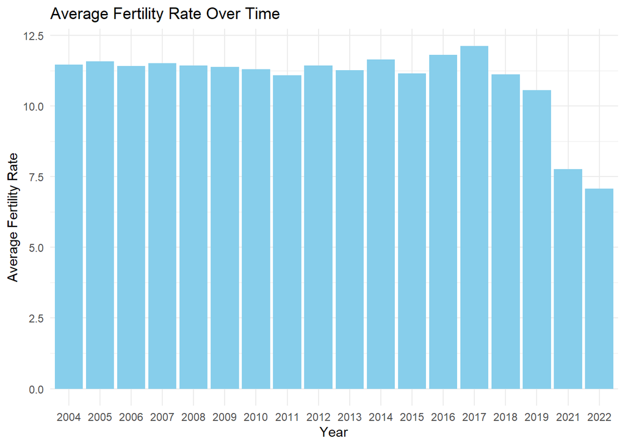

```r
average_fertility_rate <- aggregate(fertility_rate ~ year, data = final_data_wide, FUN = mean)
average_capita<- aggregate(per_capita_residential_sales ~ year, data = final_data_wide, FUN = mean)
Fertility_plot <- ggplot(average_capita, aes(x = year, y = per_capita_residential_sales)) +
  geom_bar(stat = "identity", fill = "skyblue") +
  labs(
    x = "Year",
    y = "Average Fertility Rate",
    title = "Average Fertility Rate Over Time"
  ) +
  theme_minimal()

Fertility_plot <- ggplot(average_fertility_rate, aes(x = year, y = fertility_rate)) +
  geom_bar(stat = "identity", fill = "skyblue") +
  labs(
    x = "Year",
    y = "Average Fertility Rate",
    title = "Average Fertility Rate Over Time"
  ) +
  theme_minimal()

Fertility_plot
```

From the above chart, it can be observed that from 2004 to 2015, the birth rate remained relatively stable, hovering around 11‰. There was a slight increase from 2016 to 2017. However, starting in 2018, the birth rate began to decline sharply, falling below 7.5‰ by 2022.

To analyze the reasons for this rapid decline:

1.Population Policy Adjustments: Changes in population policies could be a significant factor influencing the variations in birth rates.

2.Economic Factors: With the improvement in economic development, living costs and educational expenses have been continuously increasing. This may lead to couples delaying childbirth or choosing not to have children, contributing to the decline in birth rates.

3.Changes in Social Structure: The acceleration of urbanization and changes in lifestyle have altered family structures and living patterns. These changes might affect people’s attitudes towards childbirth and their decisions regarding having children.

```r
data_to_map <- final_data_wide[, c("province", "year", "fertility_rate")]

# Convert map data (DBDQ2) to sf objects
DBDQ2_sf <- st_as_sf(DBDQ2)


# Create a list to store map objects
map_list <- list()

# Loop over three years and draw the map and store it in the list
for (year in c(2012, 2016, 2022)) {
  data_year <- data_to_map[data_to_map$year == year, ]
  # Merge data and map boundaries
  data_map <- left_join(DBDQ2_sf, data_year, by = c("name_1" = "province"))
  map <- tm_shape(data_map) +
    tm_polygons(col = "fertility_rate",
                style = "quantile",
                n = 5,
                palette = "Blues",
                title = paste("Fertility Rate in", year),
                legend.position = c("right", "bottom"),
                textNA = "Missing Data",
                border.col = "grey50") +
    tm_layout(title.position = c("center", "top"))
  print(as.data.frame(data_map[,c(117,119,120)]))
  map_list[[length(map_list) + 1]] <- map
}
```

```
##    Urban_to_T    DZM   NAME                       geometry
## 1       51.54 230000 黑龙江 MULTIPOLYGON (((1329152 561...
## 2       33.82 650000   新疆 MULTIPOLYGON (((-2189253 46...
## 3       34.91 140000   山西 MULTIPOLYGON (((761692.1 44...
## 4       32.43 640000   宁夏 MULTIPOLYGON (((-34477.05 4...
## 5       18.93 540000   西藏 MULTIPOLYGON (((-2189253 46...
## 6       38.00 370000   山东 MULTIPOLYGON (((915805.7 44...
## 7       23.20 410000   河南 MULTIPOLYGON (((915805.7 44...
## 8       41.49 320000   江苏 MULTIPOLYGON (((1261146 438...
## 9       27.81 340000   安徽 MULTIPOLYGON (((1016688 428...
## 10      40.22 420000   湖北 MULTIPOLYGON (((547929.6 40...
## 11      48.67 330000   浙江 MULTIPOLYGON (((1509096 396...
## 12      27.67 360000   江西 MULTIPOLYGON (((1128792 379...
## 13      29.75 430000   湖南 MULTIPOLYGON (((603782.5 37...
## 14      23.36 530000   云南 MULTIPOLYGON (((-570115.7 3...
```

[output cut: 90 more lines]

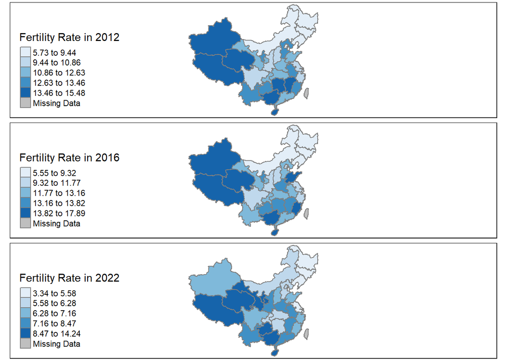

```r
# Creating a map object
maps_combined <- tmap_arrange(map_list[[1]], map_list[[2]], map_list[[3]], nrow = 3, ncol = 1)

maps_combined
```

Based on the above chart, the spatial distribution and changes in birth rates across China’s provinces can be observed for the years 2012, 2016, and 2022.

In 2012, the birth rates were relatively high in the northwest regions such as Xinjiang, Qinghai, and Tibet, with rates of 15.32‰, 14.30‰, and 15.48‰ respectively. Conversely, the northeastern regions, including Jilin, Liaoning, and Heilongjiang, had lower birth rates, recorded at 5.73‰, 6.15‰, and 6.60‰ respectively.

By 2016, Shandong’s birth rate had significantly increased to 17.89‰, surpassing Xinjiang in the northwest to become the province with the highest birth rate. Fujian also saw a substantial rise in its birth rate, reaching 14.50‰. Meanwhile, the northern regions of Jilin, Heilongjiang, and Liaoning continued to maintain low birth rates.

# Analysis of spatial clustering effect of birth rate

Using the Moran’s Index to detect spatial autocorrelation in geographic data involves determining whether the data values of a particular region are related to those of neighboring regions. If the Moran’s Index is significantly positive, it indicates the presence of spatial clustering effects; if negative, it indicates spatial dispersion effects.

If the data show spatial dependence, one might consider using spatial regression models for variable analysis.

Additionally, by examining the changes in the Moran’s Index over different years, we can observe the spatial distribution changes in birth rates before and after the implementation of the second-child policy. If the second-child policy impacts birth rates, it may lead to changes in the Moran’s Index, such as an increase or decrease in clustering effects.

```r
DBDQ$province <- c("Xinjiang", "Tibet", "Qinghai", "Gansu", "Sichuan", "Chongqin", "Guizhou",
                   "Yunnan", "Ningxia", "Shaanxi", "Guangxi", "Hainan", "Guangdong", "Hunan", "Jiangxi",
                   "Fujian", "Taiwan", "Zhejiang", "Shanghai", "Hubei", "Anhui", "Jiangsu", "Henan", "Shandong",
                   "Hebei", "Shanxi","Mongolia", "Tianjin","Liaoning", "Jilin", "Heilongjiang",  "Beijing", "Hong Kong",
                   "Macao")

# Combine final_data_wide and DBDQ
final_data_geo <- left_join(final_data_wide, DBDQ, by = c("province" = "province"))
final_data_geo <- final_data_geo[,c(1:15,18)]


# Create a data frame to store results
moran_results <- data.frame(year = c(2004:2019,2021:2022),
                            moran_I = numeric(18),
                            p_value = numeric(18),
                            z_value = numeric(18))

# Loop over each year and calculate Moran's I
for (i in 1:18) {
  # Filter data for the specific year
  data_year <- final_data_geo[final_data_geo$year == moran_results$year[i], ]

  # Extract coordinates
  coords <- st_coordinates(st_as_sf(data_year))
  coords_df <- data.frame(X = coords[, 1], Y = coords[, 2])
  coords_mat <- as.matrix(coords_df)

  # Calculate k-nearest neighbor spatial weights
  nb <- knn2nb(knearneigh(coords_mat, k = 15))
  listw <- nb2listw(nb, style = "B", zero.policy = TRUE)

  # Calculate Moran's I
  moran_results$moran_I[i] <- moran(data_year$fertility_rate, listw, n = 31, S0=Szero(listw))$I
  moran_mc <- moran.mc(data_year$fertility_rate, listw, nsim=999)


  # Store p-value and Z-value

  moran_results$p_value[i] <- moran_mc$p.value
  moran_results$z_value[i] <- (moran_results$moran_I[i] - mean(moran_mc$res)) / sd(moran_mc$res)
}
```

[output not shown]

```r
# Print the result
print(moran_results)
```

```
##    year   moran_I p_value  z_value
## 1  2004 0.1619796   0.001 5.279577
## 2  2005 0.1457399   0.001 4.739952
## 3  2006 0.1460834   0.001 4.529811
## 4  2007 0.1321213   0.002 4.452328
## 5  2008 0.1498702   0.001 5.022557
## 6  2009 0.1439879   0.001 5.024128
## 7  2010 0.1284879   0.003 4.292671
## 8  2011 0.1651961   0.001 5.427445
## 9  2012 0.1827392   0.001 5.940468
## 10 2013 0.1728096   0.001 5.624776
## 11 2014 0.1397892   0.002 4.853874
## 12 2015 0.2203714   0.001 6.481266
## 13 2016 0.1406952   0.001 4.797069
## 14 2017 0.1558423   0.001 5.045716
## 15 2018 0.2516178   0.001 7.497775
## 16 2019 0.2277105   0.001 6.931149
## 17 2021 0.1694895   0.002 5.036110
## 18 2022 0.1643531   0.001 5.223509
```

Moran’s I Values:

The Moran’s Index values for all years are positive, indicating that there is spatial positive autocorrelation in the birth rates among Chinese provinces during these years. This means that provinces with high birth rates tend to be adjacent to other provinces with high birth rates, and provinces with low birth rates tend to be adjacent to other provinces with low birth rates.

p-values:

All p-values are less than 0.05 (with most years having a p-value of 0.001), indicating that the Moran’s Index is statistically significant. This means we can reject the null hypothesis of zero spatial autocorrelation, further supporting the presence of spatial positive autocorrelation.

z-values:

The significant spatial autocorrelation indicated by the Moran’s Index shows a notable spatial clustering effect in birth rates across provinces, and it is essential to evaluate the geographic impact of the second-child policy. In subsequent spatial econometric model analyses, spatial dependence must be considered. Appropriate spatial regression models (such as the spatial lag model or the spatial error model) can be chosen to further analyze the factors influencing birth rates and the effects of the policy.

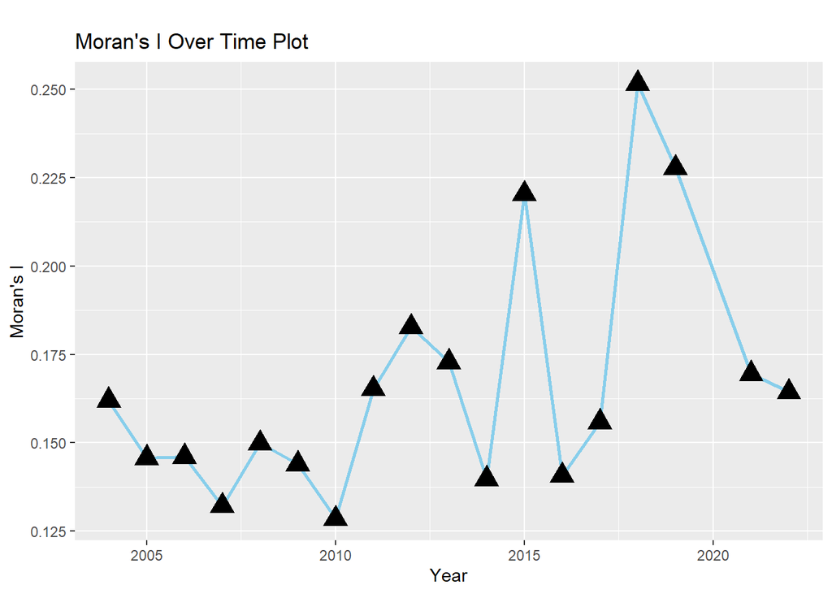

```r
ggplot(moran_results, aes(x = year, y = moran_I)) +
  geom_line(color = "skyblue", size = 1) +
  geom_point(shape = 17, size = 5, fill = "skyblue") +
  labs(title = "
Moran's I Over Time Plot", x = "Year", y = "Moran's I")
```

Over time, the Moran’s I value fluctuated between 2004 and 2019, but overall it exhibited stable spatial autocorrelation. This indicates that there is a consistent spatial pattern in birth rates among Chinese provinces and cities.

However, it is important to note that the global COVID-19 pandemic since 2020 may have impacted birth rates in China. Although the specific effects of the pandemic on birth rates are not yet clear, it is likely that the pandemic has altered people’s lifestyles, which in turn affects their fertility intentions and behaviors. For example, economic instability, increased employment pressures, and strained medical resources may lead some families to delay or forgo having children. Therefore, we cannot ignore the potential impact of the pandemic on the spatial distribution and trends of birth rates in China, and further in-depth research is needed in the future.

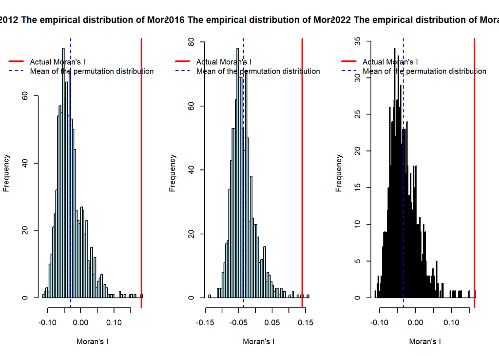

```r
data_year_c <- c(2012, 2016, 2022)
par(mfrow = c(1, 3), mar = c(5, 4, 4, 2) + 0.1)

# Loop over each year and calculate Moran's I
for (i in 1:3) {
  # Filter data for the specific year
  data_year <- final_data_geo[final_data_geo$year == data_year_c[i], ]

  # Extract coordinates
  coords <- st_coordinates(st_as_sf(data_year))
  coords_df <- data.frame(X = coords[, 1], Y = coords[, 2])
  coords_mat <- as.matrix(coords_df)

  # Calculate k-nearest neighbor spatial weights
  nb <- knn2nb(knearneigh(coords_mat, k = 15))
  listw <- nb2listw(nb, style = "B", zero.policy = TRUE)

  # Calculate Moran's I
  moran_I <- moran(data_year$fertility_rate, listw, n = 31, S0=Szero(listw))$I

  # Perform Monte Carlo simulation
  moran_mc <- moran.mc(data_year$fertility_rate, listw, nsim = 999)

  moran_zvalue <- (moran_I - mean(moran_mc$res)) / sd(moran_mc$res)

  hist(moran_mc$res, breaks=100, col="lightblue",
       main=paste(data_year_c[i], "The empirical distribution of Moran's I"),
       xlab="Moran's I", ylab="Frequency")

  # Add the real Moran's I values
  abline(v = moran_I, col = "red", lwd = 2)

  # Add the mean of the permutation distribution
  abline(v = mean(moran_mc$res), col = "blue", lty = 2)

  # Add pseudo p-values
  text(x = moran_I, y = 500, labels = paste("p =", round(moran_mc$p.value, 4)), col = "red")

  legend("topright", legend=c("Actual Moran's I", "Mean of the permutation distribution"),
         col=c("red", "blue"), lty=c(1, 2), lwd=c(2, 1), inset=c(-0.1, 0.05), bty="n", xpd=NA)
}
```

The above charts show the histograms of the empirical distribution of Moran’s Index (Moran’s I) for the years 2012, 2016, and 2022.

In all three years, the actual Moran’s Index values are positive and significantly greater than the mean of the permutation distribution. The actual Moran’s Index values are located far to the right of the positive skew, with very low p-values, indicating that this spatial autocorrelation is statistically highly significant.

From 2012 to 2022, the birth rates in each province consistently exhibited significant positive spatial autocorrelation. This means that provinces with high birth rates are adjacent to other provinces with high birth rates, and provinces with low birth rates are adjacent to other provinces with low birth rates. This indicates a geographic clustering phenomenon in birth rates.

# Local spatial aggregation effect

Local Spatial Autocorrelation refers to the phenomenon where the attribute values of a specific region (such as birth rate, income level, etc.) are similar or correlated with those of neighboring regions in geographic space. This can be specifically manifested in the following types:

High-High Cluster (HH): Areas with high attribute values are surrounded by areas with high attribute values. Low-Low Cluster (LL): Areas with low attribute values are surrounded by areas with low attribute values. High-Low Cluster (HL): Areas with high attribute values are surrounded by areas with low attribute values. Low-High Cluster (LH): Areas with low attribute values are surrounded by areas with high attribute values.

Meaning of Local Moran’s Index:

Positive Value: Indicates that the attribute values of the region are similar to those of neighboring regions, i.e., high values are surrounded by high values or low values are surrounded by low values, demonstrating positive spatial autocorrelation.

Negative Value: Indicates that the attribute values of the region are opposite to those of neighboring regions, i.e., high values are surrounded by low values or low values are surrounded by high values, demonstrating negative spatial autocorrelation.

Significance Test: Using methods such as Monte Carlo simulation to test the significance of the Local Moran’s Index, determining whether the spatial clustering effect is statistically significant.

```r
moran_city <- data.frame(province = character(),
                         year = character(),
                         moran_level = character(),
                         stringsAsFactors = FALSE)
# Create a data frame to store the results of the significance test
lisa_results <- data.frame(
  province = character(),
  year = character(),
  moran_level = character(),
  significant = numeric(),
  spatial_lag=numeric()
)

sca_plot <- list()
data_year_b <- c(2004:2019,2021:2022)
```

```r
# Loop over each year and calculate Moran's I
for (i in 1:18) {
  # Filter data for the specific year
  data_year <- final_data_geo[final_data_geo$year == data_year_b[i], ]

  # Extract coordinates
  coords <- st_coordinates(st_as_sf(data_year))
  coords_df <- data.frame(X = coords[, 1], Y = coords[, 2])
  coords_mat <- as.matrix(coords_df)

  # Calculate k-nearest neighbor spatial weights
  nb <- knn2nb(knearneigh(coords_mat, k = 15))
  listw <- nb2listw(nb, style = "W", zero.policy = TRUE)

  local_moran <- localmoran(x = data_year$fertility_rate, listw = listw)
  local_moran
  # Local Moran's I results were extracted for each province
  local_moran_values <- local_moran[,1]

  spatial_lag <- lag.listw(listw, local_moran_values)

  df <- data.frame(fertility_rate = data_year$fertility_rate, spatial_lag = spatial_lag)

  sca_plot[[i]]<-  ggplot(df, aes(x = fertility_rate, y = spatial_lag)) +
    geom_point() +
    # Add a horizontal line and a vertical line centered on the mean
    geom_hline(yintercept = mean(df$spatial_lag), linetype = "dashed") +
    geom_vline(xintercept = mean(df$fertility_rate), linetype = "dashed") +
    labs(title = paste(data_year_b[i],"Spatial Lag Scatterplot"),
         x = "Standardized Fertility Rate",
         y = "Spatial Lag of Fertility Rate")
  moran_levels <- as.vector(attr(local_moran, "quadr")[, "mean"])
  moran_city2 <- as.data.frame(cbind(province=data_year$province,year=data_year$year,moran_levels))
  moran_city <- rbind(moran_city,moran_city2)

  # Significance tests were performed
  significant <- local_moran[,5]
  quadrants <- attr(local_moran, "quadr")[, "mean"]

  lisa_results2 <- data.frame(
    province = data_year$province,
    year = data_year$year,
    moran_level = quadrants,
    significant = significant,
    spatial_lag=spatial_lag
  )

  lisa_results <- rbind(lisa_results,lisa_results2)


}
```

[output not shown]

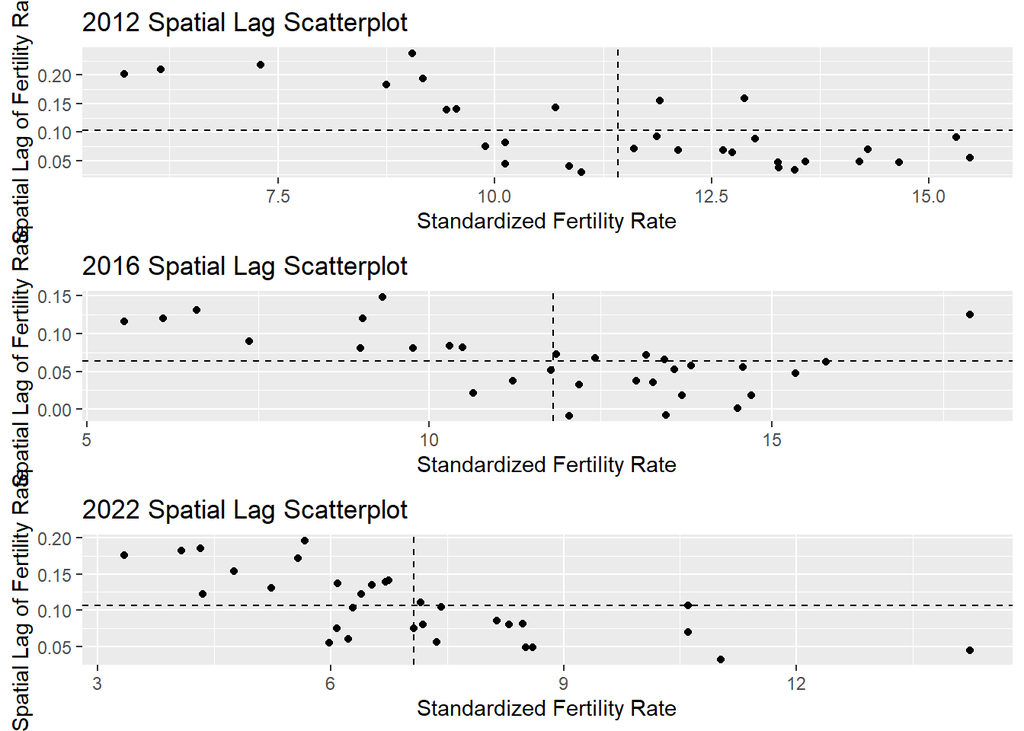

```r
grid.arrange(sca_plot[[9]], sca_plot[[13]], sca_plot[[18]], ncol = 1)
```

Scatter Plots of Standardized Birth Rates and Their Spatial Lag for 2012, 2016, and 2022

Analysis:

The scatter plots of local spatial instability reveal a certain degree of spatial heterogeneity in birth rates across Chinese provinces and cities, exhibiting various clustering phenomena, including H-H, L-H, L-L, and H-L types.

Particularly in 2022, there is a noticeable decrease in the first quadrant. This decrease may reflect changes in the spatial correlation of birth rates. From the perspective of spatial correlation, this change could indicate that the differences in birth rates between provinces and cities are gradually narrowing, suggesting that birth rates are becoming more balanced or similar spatially.

Several factors might influence this trend change. On one hand, it may be due to the government implementing a series of nationwide population policies, such as relaxing birth policies or strengthening their enforcement, leading to more consistent birth rates across regions. On the other hand, economic development disparities might also influence the spatial correlation of birth rates. If regional economic development levels are becoming more similar, it could lead to reduced differences in birth rates.

Therefore, the noticeable decrease in the first quadrant in 2022 might be the result of these combined factors. This trend change merits further attention and research to better understand the spatial evolution of birth rates and to provide insights for future population policy formulation.

```r
a <- lisa_results[lisa_results$year%in%c(2012,2016,2022),]
print(lisa_results[lisa_results$year%in%c(2012,2016,2022),])
```

```
##          province year moran_level significant  spatial_lag
## 129       Beijing 2012     Low-Low 0.001752214  0.238700828
## 229       Tianjin 2012     Low-Low 0.006680900  0.183654235
## 39          Hebei 2012    High-Low 0.039537632  0.158617495
## 48         Shanxi 2012     Low-Low 0.456081962  0.142763290
## 58       Mongolia 2012     Low-Low 0.078790328  0.194264746
## 68       Liaoning 2012     Low-Low 0.001816520  0.209438965
## 78          Jilin 2012     Low-Low 0.001075411  0.202464026
## 88   Heilongjiang 2012     Low-Low 0.001221205  0.218203399
## 98       Shanghai 2012     Low-Low 0.281568932  0.140075763
## 108       Jiangsu 2012     Low-Low 0.284819583  0.139679295
## 1112     Zhejiang 2012     Low-Low 0.738460370  0.081703340
## 1210        Anhui 2012    High-Low 0.588831087  0.088465103
## 138        Fujian 2012   High-High 0.255987200  0.064056599
## 148       Jiangxi 2012   High-High 0.403125167  0.033088848
```

[output cut: 79 more lines]

# LISA (Local Indicator of Spatial Autocorrelation)

[figure not shown]

```r
lisa_results$year <- as.numeric(lisa_results$year )
map <- list()


DBDQ2 <- st_as_sf(DBDQ2)
map <- list()

for (i in 1:3) {
  merged_data <- inner_join(lisa_results[lisa_results$year == data_year_c[i],], DBDQ2, by = c("province" = "name_1"))

  geom_col <- st_geometry(DBDQ2)
  merged_data <- cbind(merged_data, geometry = geom_col[match(merged_data$province, DBDQ2$name_1)])
  merged_data <- st_as_sf(merged_data)

  merged_data$moran_level <- ifelse(merged_data$significant > 0.05, 'non-significant', as.character(merged_data$moran_level))

  map[[i]] <- ggplot() +
    geom_sf(data = merged_data, aes(fill = moran_level)) +
    scale_fill_manual(values = c("Low-Low" = "blue", "High-Low" = "green", "Low-High" = "orange",
                                 "High-High" = "red", 'non-significant' = 'gray')) +
    labs(title = paste(data_year_c[i], "Moran Level by Province")) +
    theme_minimal()
}
grid.arrange(map[[1]], map[[2]], map[[3]], ncol = 3)
```

```r
as.data.frame(merged_data)[,1:2]
```

```
##        province year
## 1       Beijing 2022
## 2       Tianjin 2022
## 3         Hebei 2022
## 4        Shanxi 2022
## 5      Mongolia 2022
## 6      Liaoning 2022
## 7         Jilin 2022
## 8  Heilongjiang 2022
## 9      Shanghai 2022
## 10      Jiangsu 2022
## 11     Zhejiang 2022
## 12        Anhui 2022
## 13       Fujian 2022
## 14      Jiangxi 2022
```

[output cut: 17 more lines]

2012: The birth rates exhibited significant spatial heterogeneity, with clustering phenomena of H-H, L-H, L-L, and H-L types.

L-L Clustering: Predominantly found in the northern regions, including the three northeastern provinces and the North China region, such as Liaoning, Jilin, and Heilongjiang. These areas had relatively low and similar birth rates, potentially influenced by economic development levels and population policies.

H-H Clustering remained significant in the southern regions. And L-L Clustering continued in the northern regions, indicating that the differences in birth rates between the southern and northern regions were maintained to some extent.

2022:

In 2022, the number of H-H clustering areas further increased, with more pronounced clustering in the southern regions.

L-L Clustering persisted in the North China region, indicating that the pattern of relatively low birth rates in the northern regions had not changed significantly.

```r
# An empty data frame to store the results
result <- data.frame(
  Year = character(),
  Total_Theil = numeric(),
  Region_Theil_Within = numeric(),
  Region_Theil_Between = numeric(),
  Total_Contribution_Within = numeric(),
  Total_Contribution_Between = numeric(),
  stringsAsFactors = FALSE
)
```

# Analysis of regional differences in birth rate

Based on the spatial clustering of birth rates and the heterogeneity among provinces and cities, 31 provinces and cities were divided into four groups to analyze their regional differences:

Group 1 (TW1): Includes Liaoning, Tianjin, Jilin, Heilongjiang, Beijing, Hebei, Inner Mongolia, and Shanxi. These provinces and cities have relatively low birth rates, showing low-low clustering, and are mainly distributed in the northern regions of China.

Group 2 (TW2): Includes Tibet, Qinghai, Yunnan, Guizhou, Xinjiang, Ningxia, Guangxi, Gansu, and Hainan. These regions have relatively high birth rates and are broadly distributed, primarily concentrated in the western regions of China.

Group 3 (TW3): Mainly covers the central and some southwestern regions, including Shaanxi, Sichuan, Chongqing, Hubei, Hunan, and Henan. The birth rates in these provinces and cities are at a medium level.

Group 4 (TW4): Primarily located in the eastern regions, including Jiangxi, Fujian, Shandong, Anhui, Zhejiang, Jiangsu, Shanghai, and Guangdong. These regions have relatively high birth rates.

Subsequently, the Theil index was calculated for different years.

The Theil index is a statistical measure used to assess economic inequality or the distribution of a particular variable, such as income, within a population. It is part of the generalized entropy class of measures and provides insights into disparities by decomposing overall inequality into within-group and between-group components.

The 𝑇index represents the overall Theil index. Tw1 represents the within-group Theil index for the first group, Tw2 represents the within-group Theil index for the second group, Tw3 represents the within-group Theil index for the third group, and Tw4 represents the within-group Theil index for the fourth group. Db and Dw represent the contribution of between-group differences and within-group differences to the overall inequality, respectively.

# Data preparation

```r
# Loop through the Theil index for each year

region_mapping <- c(
  "North" = c("Beijing", "Tianjin", "Hebei", "Shanxi", "Mongolia"),
  "Northeast" = c("Liaoning", "Jilin", "Heilongjiang"),
  "East" = c("Shanghai", "Jiangsu", "Zhejiang", "Anhui", "Fujian", "Jiangxi", "Shandong"),
  "Central South" = c("Henan", "Hubei", "Hunan", "Guangdong", "Guangxi", "Hainan"),
  "Southwest" = c("Chongqin", "Sichuan", "Guizhou", "Yunnan", "Tibet"),
  "Northwest" = c("Shaanxi", "Gansu", "Qinghai", "Ningxia", "Xinjiang")
)

# Adds a region column to the data frame
final_data_geo$region <- NA
for (region in names(region_mapping)) {
  final_data_geo$region[final_data_geo$province %in% region_mapping[[region]]] <- region
}
final_data_geo$region <- sub("\\d+$", "", final_data_geo$region)

group1 <- c("Liaoning", "Tianjin", "Jilin", "Heilongjiang", "Beijing", "Hebei", "Mongolia", "Shanxi")
group2 <- c("Tibet", "Qinghai", "Yunnan", "Guizhou", "Xinjiang", "Ningxia", "Guangxi", "Gansu", "Hainan")
group3 <- c("Shaanxi", "Sichuan", "Chongqin", "Hubei", "Hunan", "Henan")
group4 <- c("Jiangxi", "Fujian", "Shandong", "Anhui", "Zhejiang", "Jiangsu", "Shanghai", "Guangdong")

TW_all <- final_data_geo[final_data_geo$year%in%c(2012,2016,2022),c(17,15,1,2)]
TW_all$region <- ifelse(TW_all$province%in%group1,'TW1',
                        ifelse(TW_all$province%in%group2,'TW2',
                               ifelse(TW_all$province%in%group3,'TW3',
                                      'TW4')))
```

```r
#Define the Theil index calculation function
TY_index <- function(x) {
  n <- length(x)
  mean_x <- mean(x)
  term1 <- sum(x * log(x / mean_x))
  term2 <- sum(x) * log(sum(x) / (n * mean_x))
  tindex <- term1 - term2
  return(tindex)
}

# Calculate Theil index for each group and year
theil_indices <- list()

for (year in c('2022', '2016', '2012')) {
  # Subset the data for the current year
  TW_year <- TW_all[TW_all$year == year, ]

  # Calculate Theil index for each group
  TW <- TW_year %>%
    group_by(region) %>%
    summarize(tindex = TY_index(fertility_rate))

  # Calculate total Theil index (T)
  tindex <- TY_index(TW_year$fertility_rate)

  # Calculate between-group Theil index (Tb)
  Tb <- mean(TW$tindex)

  # Calculate within-group Theil index (Tw)
  Tw <- tindex - Tb

  # Calculate the contributions of between-group and within-group differences to the total difference (Db and Dw)
  Db <- Tb / tindex
  Dw <- Tw / tindex

  # Store the results for the current year in the theil_indices list
  theil_indices[[year]] <- c(
    TW1 = TW$tindex[1],
    TW2 = TW$tindex[2],
    TW3 = TW$tindex[3],
    TW4 = TW$tindex[4],
    tindex = tindex,
    Db = Db,
    Dw = Dw
  )
}

# Convert the list to a data frame
theil_indices_df <- data.frame(
  year = rep(c('2022', '2016', '2012'), each = length(theil_indices[[year]])),
  region = rep(names(theil_indices[[year]]), times = 3),
  value = unlist(theil_indices)
)

theil_indices_df
```

```
##             year region       value
## 2022.TW1    2022    TW1  0.91558757
## 2022.TW2    2022    TW2  2.03481135
## 2022.TW3    2022    TW3  0.15594367
## 2022.TW4    2022    TW4  0.86336072
## 2022.tindex 2022 tindex 10.50565449
## 2022.Db     2022     Db  0.09446587
## 2022.Dw     2022     Dw  0.90553413
## 2016.TW1    2016    TW1  2.27136260
## 2016.TW2    2016    TW2  0.36474502
## 2016.TW3    2016    TW3  0.34509590
## 2016.TW4    2016    TW4  2.17298641
## 2016.tindex 2016 tindex 11.75716465
## 2016.Db     2016     Db  0.10959679
## 2016.Dw     2016     Dw  0.89040321
## 2012.TW1    2012    TW1  2.22007429
## 2012.TW2    2012    TW2  0.39589645
## 2012.TW3    2012    TW3  0.39682598
## 2012.TW4    2012    TW4  0.78046297
## 2012.tindex 2012 tindex  8.88612423
## 2012.Db     2012     Db  0.10671862
## 2012.Dw     2012     Dw  0.89328138
```

```r
theil_indices_wide <- pivot_wider(
  data = theil_indices_df,
  names_from = region,
  values_from = value
)

columns_to_scale <- c("TW1", "TW2", "TW3", "TW4", "tindex")

theil_indices_wide_scaled <- theil_indices_wide %>%
  mutate(across(all_of(columns_to_scale), ~ scale(.x, center = min(.x), scale = max(.x) - min(.x)) * 0.028 + 0.002))

# Extract the data for 2022
theil_indices_wide_scaled <- theil_indices_wide_scaled[theil_indices_wide_scaled$year == 2022, ]

theil_indices_wide_scaled
```

```
## # A tibble: 1 × 8
##   year  TW1[,1] TW2[,1] TW3[,1] TW4[,1] tindex[,1]     Db    Dw
##   <chr>   <dbl>   <dbl>   <dbl>   <dbl>      <dbl>  <dbl> <dbl>
## 1 2022    0.002    0.03   0.002 0.00367     0.0178 0.0945 0.906
```

```r
# Convert the list to a data frame
theil_indices_df <- data.frame(
  year = rep(c('2022', '2016', '2012'), each = length(theil_indices[[year]])),
  region = rep(names(theil_indices[[year]]), times = 3),
  value = unlist(theil_indices)
)

theil_indices_df
```

```
##             year region       value
## 2022.TW1    2022    TW1  0.91558757
## 2022.TW2    2022    TW2  2.03481135
## 2022.TW3    2022    TW3  0.15594367
## 2022.TW4    2022    TW4  0.86336072
## 2022.tindex 2022 tindex 10.50565449
## 2022.Db     2022     Db  0.09446587
## 2022.Dw     2022     Dw  0.90553413
## 2016.TW1    2016    TW1  2.27136260
## 2016.TW2    2016    TW2  0.36474502
## 2016.TW3    2016    TW3  0.34509590
## 2016.TW4    2016    TW4  2.17298641
## 2016.tindex 2016 tindex 11.75716465
## 2016.Db     2016     Db  0.10959679
## 2016.Dw     2016     Dw  0.89040321
## 2012.TW1    2012    TW1  2.22007429
## 2012.TW2    2012    TW2  0.39589645
## 2012.TW3    2012    TW3  0.39682598
## 2012.TW4    2012    TW4  0.78046297
## 2012.tindex 2012 tindex  8.88612423
## 2012.Db     2012     Db  0.10671862
## 2012.Dw     2012     Dw  0.89328138
```

```r
# Reshape the data from long to wide format
theil_indices_wide <- pivot_wider(
  data = theil_indices_df,
  names_from = region,
  values_from = value
)

theil_indices_wide
```

```
## # A tibble: 3 × 8
##   year    TW1   TW2   TW3   TW4 tindex     Db    Dw
##   <chr> <dbl> <dbl> <dbl> <dbl>  <dbl>  <dbl> <dbl>
## 1 2022  0.916 2.03  0.156 0.863  10.5  0.0945 0.906
## 2 2016  2.27  0.365 0.345 2.17   11.8  0.110  0.890
## 3 2012  2.22  0.396 0.397 0.780   8.89 0.107  0.893
```

```r
columns_to_scale <- c("TW1", "TW2", "TW3", "TW4", "tindex")

# Scale the specified columns
theil_indices_wide_scaled <- theil_indices_wide %>%
  mutate(across(all_of(columns_to_scale), ~ scale(.x, center = min(.x), scale = max(.x) - min(.x)) * 0.028 + 0.002))

theil_indices_wide_scaled <- theil_indices_wide_scaled[theil_indices_wide_scaled$year==2022,]

theil_indices_wide_scaled
```

```
## # A tibble: 1 × 8
##   year  TW1[,1] TW2[,1] TW3[,1] TW4[,1] tindex[,1]     Db    Dw
##   <chr>   <dbl>   <dbl>   <dbl>   <dbl>      <dbl>  <dbl> <dbl>
## 1 2022    0.002    0.03   0.002 0.00367     0.0178 0.0945 0.906
```

The Theil Index for Different Regions:

The overall Theil index (tindex) is 0.0177946, indicating the overall level of inequality. In the scaled data, the overall inequality level is 0.0177946, suggesting a certain degree of inequality overall.

The between-group inequality contribution (Db) is 0.0944659, representing the contribution of inequality between different groups to the overall inequality. In 2022, the contribution of between-group inequality is 0.0944659, indicating that the inequality between different regions contributes little to the overall inequality.

The within-group inequality contribution (Dw) is 0.9055341, representing the contribution of inequality within the same group to the overall inequality. In 2022, the contribution of within-group inequality is 0.9055341, indicating that inequality within the same group contributes significantly to the overall inequality.

[figure not shown]

```r
# Creating a data frame
theil_indices_wide_scaled <- data.frame(
  year = c(2012, 2016, 2022),
  tindex = c(0.018, 0.027, 0.002),
  tb= c(0.006, 0.017, 0.001),
  tw= c(0.012, 0.01, 0.001),
  TW1= c(0.041, 0.042, 0.001),
  TW2= c(0.003, 0.002, 0.002),
  TW3= c(0.006, 0.005, 0.004),
  TW4= c(0.007, 0.023, 0.018),
  Db= c(0.355, 0.63, 0.094),
  Dw =c(0.645,0.37,0.906),

  stringsAsFactors = FALSE
)

ggplot(theil_indices_wide_scaled, aes(x = year)) +
  geom_line(aes(y = TW1, color = "TW1")) +
  geom_line(aes(y = TW2, color = "TW2")) +
  geom_line(aes(y = TW3, color = "TW3")) +
  geom_line(aes(y = TW4, color = "TW4")) +
  geom_line(aes(y = tindex, color = "tindex")) +
  geom_point(aes(y = TW1, color = "TW1"), shape = 16,size=8) +
  geom_point(aes(y = TW2, color = "TW2"), shape = 16,size=8) +
  geom_point(aes(y = TW3, color = "TW3"), shape = 16,size=8) +
  geom_point(aes(y = TW4, color = "TW4"), shape = 16,size=8) +
  geom_point(aes(y = tindex, color = "tindex"), shape = 16,size=8) +
  geom_text(aes(label = sprintf("%.3f", tindex), y = tindex), vjust = -0.5, hjust = -0.5, color = "blue") +
  geom_text(aes(label = sprintf("%.3f", TW1), y = TW1), vjust = -0.5, hjust = -0.5, color = "orange") +
  geom_text(aes(label = sprintf("%.3f", TW2), y = TW2), vjust = -0.5, hjust = -0.5, color = "purple") +
  geom_text(aes(label = sprintf("%.3f", TW3), y = TW3), vjust = -0.5, hjust = -0.5, color = "brown") +
  geom_text(aes(label = sprintf("%.3f", TW4), y = TW4), vjust = -0.5, hjust = -0.5, color = "pink") +
  labs(title = "Theil Index Over Years", y = "Value", color = "Index Type") +
  scale_color_manual(values = c("TW1" = "blue", "TW2" = "orange", "TW3" = "green", "TW4" = "red", "tindex" = "purple")) +
  theme_minimal()
```

[figure not shown]

```r
ggplot(theil_indices_wide_scaled, aes(x = year)) +
  geom_line(aes(y = Dw, color = "Dw")) +
  geom_line(aes(y = Db, color = "Db")) +

  geom_point(aes(y = Dw, color = "Dw"), shape = 16,size=8) +
  geom_point(aes(y = Db, color = "Db"), shape = 16,size=8) +


  geom_text(aes(label = sprintf("%.3f", Dw), y = Dw), vjust = -0.5, hjust = -0.5, color = "orange") +
  geom_text(aes(label = sprintf("%.3f", Db), y = Db), vjust = -0.5, hjust = -0.5, color = "purple") +

  labs(title = "Theil contribution rate Over Years", y = "Value", color = "Index Type") +
  scale_color_manual(values = c( "Dw" = "orange",  "Db" = "purple")) +
  theme_minimal()
```

This trend may stem from various factors. For example, in the western regions, there may be less policy support and resource investment, making it difficult to promote population birth rates. This could include the need for more education and healthcare resources, improving maternal and child health services, and implementing policies that encourage childbirth.

In other regions, especially the TW1 area (mainly northern regions), there may be issues such as population aging and unbalanced economic development, leading to lower birth rates and thus impacting the overall Theil index.

# Empirical analysis of factors affecting fertility rate

```r
colnames(final_data_geo)
```

```
##  [1] "province"                          "year"
##  [3] "social_insurance_participation"    "urban_unemployment_rate"
##  [5] "local_fiscal_expenditure"          "GDP"
##  [7] "national_education_funding"        "education_employment_rate"
##  [9] "CPI"                               "HE_students_per_100000"
## [11] "health_technicians_per_10000"      "maternity_insurance_participation"
## [13] "per_capita_disposable_income"      "per_capita_residential_sales"
## [15] "fertility_rate"                    "geometry"
## [17] "region"
```

```r
final_data_geo
```

```
## # A tibble: 589 × 17
##    province year  social_insurance_participation urban_unemployment_rate
##    <chr>    <chr>                          <dbl>                   <dbl>
##  1 Beijing  2022                            8.62                     4.7
##  2 Beijing  2021                            8.79                     3.2
##  3 Beijing  2020                            9.17                     2.6
##  4 Beijing  2019                            9.35                     1.3
##  5 Beijing  2018                            9.53                     1.4
##  6 Beijing  2017                            9.71                     1.4
##  7 Beijing  2016                            9.83                     1.4
##  8 Beijing  2015                            8.57                     1.4
##  9 Beijing  2014                            8.58                     1.3
## 10 Beijing  2013                            8.48                     1.2
## # ℹ 579 more rows
## # ℹ 13 more variables: local_fiscal_expenditure <dbl>, GDP <dbl>,
## #   national_education_funding <dbl>, education_employment_rate <dbl>,
## #   CPI <dbl>, HE_students_per_100000 <dbl>,
## #   health_technicians_per_10000 <dbl>,
## #   maternity_insurance_participation <dbl>,
## #   per_capita_disposable_income <dbl>, per_capita_residential_sales <dbl>, …
```

```r
library(spatialreg)
library(lmtest)
library(car)
```

# Establish the spatial weight matrix

## A robustness check is performed

```r
final_data_geo$year <- as.numeric(final_data_geo$year)

# Suppose the model is named Model and the spatial weight matrix is listw
sp_data <- final_data_geo[final_data_geo$year==2012,2:15]
sp_data$second_time <- ifelse(sp_data$year<2016,0,1)
sp_data <- sp_data[,-1]
coords <- st_coordinates(st_as_sf(final_data_geo[final_data_geo$year==2012,]))
coords_df <- data.frame(X = coords[, 1], Y = coords[, 2])
coords_mat <- as.matrix(coords_df)
nb <- knn2nb(knearneigh(coords_mat, k = 15))
listw <- nb2listw(nb, style = "W", zero.policy = TRUE)
sp_data <- sp_data[, colSums(!is.na(sp_data)) > 0]
model <- lm(fertility_rate ~ ., data = sp_data)
```

```r
test_results <- lm.RStests(model, listw, test = "all", zero.policy = TRUE)
print(test_results)
```

```
##
##  Rao's score (a.k.a Lagrange multiplier) diagnostics for spatial
##  dependence
##
## data:
## model: lm(formula = fertility_rate ~ ., data = sp_data)
## test weights: listw
##
## RSerr = 0.33938, df = 1, p-value = 0.5602
##
##
##  Rao's score (a.k.a Lagrange multiplier) diagnostics for spatial
##  dependence
##
## data:
## model: lm(formula = fertility_rate ~ ., data = sp_data)
## test weights: listw
##
## RSlag = 5.3305, df = 1, p-value = 0.02096
##
##
##  Rao's score (a.k.a Lagrange multiplier) diagnostics for spatial
##  dependence
##
## data:
## model: lm(formula = fertility_rate ~ ., data = sp_data)
## test weights: listw
##
## adjRSerr = 3.5994, df = 1, p-value = 0.0578
##
##
##  Rao's score (a.k.a Lagrange multiplier) diagnostics for spatial
##  dependence
##
## data:
## model: lm(formula = fertility_rate ~ ., data = sp_data)
## test weights: listw
##
## adjRSlag = 8.5905, df = 1, p-value = 0.003379
##
##
##  Rao's score (a.k.a Lagrange multiplier) diagnostics for spatial
##  dependence
##
## data:
## model: lm(formula = fertility_rate ~ ., data = sp_data)
## test weights: listw
##
## SARMA = 8.9299, df = 2, p-value = 0.01151
```

# Spatial Lag Model (Lag Model) and Spatial Error Model (Error Model)

```r
# Calculate the Robust LM (error) statistic
lm_lag <- test_results$RSlag
print(lm_lag)
```

```
##
##  Rao's score (a.k.a Lagrange multiplier) diagnostics for spatial
##  dependence
##
## data:
## model: lm(formula = fertility_rate ~ ., data = sp_data)
## test weights: listw
##
## RSlag = 5.3305, df = 1, p-value = 0.02096
```

```r
# Calculate Robust LM (lag) statistic
robust_lm_lag <- test_results$adjRSlag
print(robust_lm_lag)
```

```
##
##  Rao's score (a.k.a Lagrange multiplier) diagnostics for spatial
##  dependence
##
## data:
## model: lm(formula = fertility_rate ~ ., data = sp_data)
## test weights: listw
##
## adjRSlag = 8.5905, df = 1, p-value = 0.003379
```

```r
# Calculate Lagrange Multiplier (error) statistic
lm_error <- test_results$RSerr
print(lm_error)
```

```
##
##  Rao's score (a.k.a Lagrange multiplier) diagnostics for spatial
##  dependence
##
## data:
## model: lm(formula = fertility_rate ~ ., data = sp_data)
## test weights: listw
##
## RSerr = 0.33938, df = 1, p-value = 0.5602
```

```r
# Calculate Robust LM (error) statistic
robust_lm_error <- test_results$adjRSerr
print(robust_lm_error)
```

```
##
##  Rao's score (a.k.a Lagrange multiplier) diagnostics for spatial
##  dependence
##
## data:
## model: lm(formula = fertility_rate ~ ., data = sp_data)
## test weights: listw
##
## adjRSerr = 3.5994, df = 1, p-value = 0.0578
```

```r
# Calculate Lagrange Multiplier (SARMA) statistic
lm_sarma <- test_results$SARMA
print(lm_sarma)
```

```
##
##  Rao's score (a.k.a Lagrange multiplier) diagnostics for spatial
##  dependence
##
## data:
## model: lm(formula = fertility_rate ~ ., data = sp_data)
## test weights: listw
##
## SARMA = 8.9299, df = 2, p-value = 0.01151
```

Lag Model:

The Rao’s Score statistic for spatial lag dependency is significant (p < 0.05), indicating a significant spatial lag effect in the model. This means that the birth rate in one region is influenced by the birth rates in neighboring regions. Additionally, the adjusted Rao’s Score statistic for spatial lag dependency is significant (p < 0.01), further confirming the significant spatial lag effect in the model.

It can be observed that factors such as education, CPI, and the proportion of higher education students have a significant impact on the spatial lag of birth rates. GDP and per capita disposable income also have a significant negative impact on the spatial lag of birth rates.

Error Model:

The Rao’s Score statistic for spatial error dependency is not significant (p > 0.05), suggesting that there is no significant spatial error effect in the model. However, the adjusted Rao’s Score statistic for spatial error dependency is close to significant at the 0.05 level (p close to 0.05), indicating a possible, but not strong, spatial error effect in the model.

The SARMA (Spatial Autoregressive Moving Average) model’s Rao’s Score statistic is significant (p < 0.05), indicating significant spatial autoregressive and moving average effects in the model. This means that the spatial dependency effect cannot be explained solely by lag or error effects, but rather, there is a more complex spatial correlation.

```r
# Fit the spatial autocorrelation model
sp_data <- final_data_geo[,2:15]
sp_data$second_time <- ifelse(sp_data$year<2016,0,1)
sp_data <- sp_data[,-1]
coords <- st_coordinates(st_as_sf(final_data_geo))
coords_df <- data.frame(X = coords[, 1], Y = coords[, 2])
coords_mat <- as.matrix(coords_df)
nb <- knn2nb(knearneigh(coords_mat, k = 15))
listw <- nb2listw(nb, style = "W", zero.policy = TRUE)

spatial_model_lag <- lagsarlm(fertility_rate ~ .,data = sp_data, listw)
spatial_model_error<- errorsarlm(fertility_rate ~ .,data = sp_data, listw)

summary(spatial_model_lag)
```

```
##
## Call:lagsarlm(formula = fertility_rate ~ ., data = sp_data, listw = listw)
##
## Residuals:
##      Min       1Q   Median       3Q      Max
## -5.63623 -0.89792  0.12452  0.88599  5.23905
##
## Type: lag
## Coefficients: (asymptotic standard errors)
##                                      Estimate  Std. Error z value  Pr(>|z|)
## (Intercept)                       -4.4768e+01  1.4479e+01 -3.0918  0.001989
## social_insurance_participation     1.7176e-02  1.4402e-02  1.1926  0.233009
## urban_unemployment_rate           -2.9142e-01  1.7093e-01 -1.7049  0.088213
## local_fiscal_expenditure          -1.4172e-04  1.6596e-04 -0.8539  0.393164
## GDP                               -4.4807e-05  2.0099e-05 -2.2294  0.025790
## national_education_funding         1.8577e-03  9.1898e-04  2.0214  0.043236
## education_employment_rate         -3.6392e-01  6.2559e-02 -5.8172 5.985e-09
## CPI                                5.5406e-01  1.3715e-01  4.0397 5.352e-05
## HE_students_per_100000            -9.1197e-04  1.9411e-04 -4.6983 2.623e-06
## health_technicians_per_10000       3.4927e-04  1.0658e-02  0.0328  0.973857
## maternity_insurance_participation -2.5467e-04  4.7078e-04 -0.5409  0.588550
## per_capita_disposable_income      -6.0511e-05  2.0843e-05 -2.9031  0.003694
## per_capita_residential_sales       1.1504e-05  3.5487e-05  0.3242  0.745812
## second_time                        4.8214e-01  2.6379e-01  1.8277  0.067591
##
## Rho: 0.68865, LR test value: 118.75, p-value: < 2.22e-16
## Asymptotic standard error: 0.034921
##     z-value: 19.72, p-value: < 2.22e-16
## Wald statistic: 388.89, p-value: < 2.22e-16
##
## Log likelihood: -460.2711 for lag model
## ML residual variance (sigma squared): 2.1096, (sigma: 1.4524)
## Number of observations: 248
## Number of parameters estimated: 16
## AIC: 952.54, (AIC for lm: 1069.3)
## LM test for residual autocorrelation
## test value: 63.417, p-value: 1.6653e-15
```

```r
summary(spatial_model_error)
```

```
##
## Call:errorsarlm(formula = fertility_rate ~ ., data = sp_data, listw = listw)
##
## Residuals:
##       Min        1Q    Median        3Q       Max
## -4.042297 -0.735370  0.025734  0.767496  4.349509
##
## Type: error
## Coefficients: (asymptotic standard errors)
##                                      Estimate  Std. Error z value  Pr(>|z|)
## (Intercept)                       -5.7943e+00  1.1145e+01 -0.5199  0.603128
## social_insurance_participation    -4.3298e-04  3.0852e-02 -0.0140  0.988803
## urban_unemployment_rate            4.6060e-01  2.0769e-01  2.2177  0.026572
## local_fiscal_expenditure           3.3046e-04  1.9721e-04  1.6757  0.093799
## GDP                                9.8279e-06  3.4007e-05  0.2890  0.772586
## national_education_funding        -8.5728e-04  1.0522e-03 -0.8148  0.415202
## education_employment_rate         -3.4444e-01  9.2098e-02 -3.7400  0.000184
## CPI                                2.5663e-01  1.0511e-01  2.4415  0.014626
## HE_students_per_100000            -2.0285e-03  3.6617e-04 -5.5398 3.028e-08
## health_technicians_per_10000       7.9532e-03  1.2068e-02  0.6590  0.509874
## maternity_insurance_participation -5.7407e-04  1.1257e-03 -0.5100  0.610079
## per_capita_disposable_income      -1.3764e-04  2.6850e-05 -5.1263 2.954e-07
## per_capita_residential_sales      -6.9876e-06  4.0437e-05 -0.1728  0.862805
## second_time                        1.1110e+00  2.4014e-01  4.6264 3.721e-06
##
## Lambda: 0.83115, LR test value: 198.53, p-value: < 2.22e-16
## Asymptotic standard error: 0.02244
##     z-value: 37.038, p-value: < 2.22e-16
## Wald statistic: 1371.8, p-value: < 2.22e-16
##
## Log likelihood: -420.381 for error model
## ML residual variance (sigma squared): 1.3552, (sigma: 1.1641)
## Number of observations: 248
## Number of parameters estimated: 16
## AIC: 872.76, (AIC for lm: 1069.3)
```

Analysis:

We find that the AIC value of the error model (872.76) is smaller than that of the lag model (952.54), indicating that the spatial error model explains the data better. This may be because the spatial error model captures the impact of spatial errors more effectively, which the spatial lag model does not consider.

By analyzing the size and significance of the coefficients, we can determine which variables are most important for influencing birth rates. For example, the coefficient for the education employment rate is -0.3444, with a very small p-value (0.000184), indicating a significant negative impact on birth rates. Additionally, the CPI coefficient is 0.2566, with a p-value of 0.0146, indicating a significant positive impact on birth rates.

Urban Unemployment Rate reflects the tension in the urban labor market. Higher unemployment rates may lead to reduced household income and economic instability, thereby lowering birth rates. In the model, the coefficient for the urban unemployment rate is positive, indicating that an increase in unemployment rate is associated with an increase in birth rates. This might reflect that reduced household income leads families to be more cautious in considering fertility issues.

Per Capita Disposable Income represents the income remaining after necessary consumption, which is an important factor for households considering fertility. Higher disposable income means families have more economic capacity to bear the cost of raising children, potentially promoting fertility. In the model, the coefficient for per capita disposable income is negative, indicating a negative correlation between birth rates and disposable income. This might reflect that higher-income families place greater emphasis on career development and personal life, thus being less willing to take on the responsibility of raising children.